# The Generational Divide

Age and Perceptions of U.S. Political Direction in Europe

Author

Joshua Bruno

## 1 Introduction

Public opinion toward the U.S. has become an increasingly important topic in Europe in recent years due to geopolitical developments, changes in U.S. leadership, and often-tense transatlantic relations resulting from a nonalignment in policy on major issues. Survey data suggest that overall favorability toward the U.S. has declined in several European countries, with significant variation across demographic groups. This study focuses specifically on age as a potential predictor of these attitudes, while accounting for individual political ideology, social class, and gender.

The analysis uses individual-level survey responses from more than 36,000 respondents across EU member states. The dependent variable is a binary indicator capturing whether respondents believe the United States is moving in the right direction or in the wrong direction. Age is treated as a continuous independent variable, and the model includes controls for political ideology, social class, and gender to isolate the relationship between age and U.S. political perceptions.

By identifying whether age is systematically related to evaluations of U.S. political direction, this paper contributes evidence to discussions about generational differences in international political attitudes within Europe. The findings provide a descriptive and statistical assessment of how opinions about the U.S. vary across age cohorts at a time of heightened geopolitical tension so close to the present day.

## 2 Research Question

**The research question is as follows:** To what extent is age associated with Europeans’ assessments of whether the United States is moving in the “right” or “wrong” direction?

This research question carries important historical implications for the future of transatlantic relations. For much of the post–World War II period, the United States has been widely regarded as a beacon of liberal democracy and it’s President commonly described as the “leader of the free world.” This reputation has played a major role in shaping European perceptions of American political legitimacy and leadership. However, recent political developments and perceived departures from these values have raised questions about whether this image remains intact, particularly among younger Europeans. If young people increasingly view the U.S. less favorably, this may signal a generational shift in how American leadership is understood and evaluated. As political influence gradually transitions from older generations to younger ones within European societies, such changes in perception could have long-term consequences for diplomatic cooperation, alliance formation, and the foundations of the transatlantic relationship.

## 3 Hypothesis

Political socialization theory argues that individuals form lasting orientations toward international actors and institutions based on the political events present during their formative years (Jennings, Stoker, & Bowers 2009, pp. 782; 793–794). On the one hand, older Europeans brought up during the Cold War or the era of post-9/11 transatlantic solidarity may maintain more favorable views of the United States due to long-standing narratives highlighting security cooperation and democratic partnership and values. On the other hand, younger Europeans have grown up in a different geopolitical environment characterized by two-party polarization within the U.S., controversial foreign policy, and a broader heightened global scrutiny of American leadership.

Consistent with this shift, the Pew Research Center (2023) finds that young adults in major European democracies exhibit significantly lower levels of trust and favorability toward the U.S. than older generations. Combined with evidence from the YouGov EuroTrack survey, which documents historically low U.S. favorability across Europe following the 2024 U.S. Presidential election, these trends suggest a generational realignment in transatlantic attitudes. Younger Europeans appear increasingly skeptical of U.S. political direction, while older Europeans maintain more positive views by comparison.

**Hypothesis:** Younger European citizens will be less likely to perceive the United States as moving in the “Right Direction” compared to older citizens, controlling for political ideology and social class.

## 4 Literature Review

A longstanding debate in political science concerns how states acquire and sustain influence in the international system. Beyond military and economic strength, scholars have emphasized the role of attraction, legitimacy, and shared values in shaping overall national might. Nye’s (1990) concept of “soft power” argues that cultural influence, political ideals, and perceived moral authority can generate support for a country’s global leadership without coercion. For much of the post-World War II period, the United States benefited disproportionately from these dynamics, particularly in Western Europe, where American ideals, cultural exchange, and institutional cooperation reinforced favorable public perceptions.

Scholarly work that came later expanded on this framework by highlighting the importance of public opinion in sustaining international influence. Research on transatlantic relations shows that European attitudes toward the United States are closely tied to evaluations of American foreign policy, democratic credibility, and global leadership (Holsti, 2008; Chiozza, 2009). Periods of perceived U.S. unilateralism or value divergence, such as during the Vietnam War or the Iraq War, have historically coincided with drops in European favorability, suggesting that support for U.S. leadership is contingent rather than remaining static.

Political socialization theory provides a useful lens through which we can begin to understand how these dynamics may differ across generations. It posits that attitudes formed during adolescence and early adulthood tend to persist over time, shaping political orientations later in life (Jennings & Niemi, 1981; Jennings et al., 2009). As a result, younger cohorts exposed to different international contexts may develop systematically different views of global actors. In the context of transatlantic relations, this implies that age-based differences in perceptions of the United States may reflect more than a mere temporary dissatisfaction, and instead signal long-term generational divides.

Recent survey evidence points to growing skepticism toward the United States across Western Europe, particularly among younger respondents. Pew Research Center (2023) finds that young adults in the United Kingdom, France, and Germany express lower confidence in U.S. global leadership and democratic performance than older cohorts. Similarly, in February 2025, YouGov’s EuroTrack surveys documented sharp declines in U.S. favorability across Europe, reaching historic lows in countries such as Denmark, Germany, and France. These findings have raised concerns about the erosion of American soft power among traditional European allies.

Despite this growing body of research, relatively little empirical work directly examines how age is associated with Europeans’ evaluations of whether the United States is moving in the “right” or “wrong” direction. Existing studies tend to focus on overall favorability or trust in leadership rather than directional assessments of U.S. politics. This study contributes to the literature by addressing this gap, using recent Eurobarometer data to assess whether age-based differences are systematically associated with perceptions of U.S. political direction at a critical moment in transatlantic relations.

## 5 Data and Descriptive Statistics

The data used in this analysis come from the Standard Eurobarometer 103, conducted in Spring 2025 and archived by the GESIS Data Archive. The Eurobarometer surveys are long-running public opinion studies that the European Commission produces and carries out through face-to-face interviews across all EU member states. These surveys aim to track the evolution of public attitudes on a wide array of social and political issues, including views on institutions, democracy, international relations, and global affairs.

Eurobarometer data are widely used in political science and sociology due to their methodological consistency, national representativeness, and inclusion of both attitudinal and demographic measures. While the survey is cross-sectional and self-reported, it remains one of the most authoritative sources of comparative public opinion data in Europe.

### 5.1 Key Variables

The dependent variable in this study is *perception of U.S. political direction*, operationalized through a survey item asking respondents whether they believe “things in the United States are going in the right direction or wrong direction.” This variable has been recoded into a binary measure (USPositive), where 1 indicates a response of “Right direction” and 0 corresponds to “Wrong direction.” Responses such as “Don’t Know” or “Refused” were excluded from the analytical sample.

The primary independent variable is Age, measured as a continuous variable in years (AgeNumeric). This allows for precise estimation of the relationship between respondent age and perceptions of U.S. political direction.

The model also includes three control variables:

- Political Ideology (IdeologyNumeric): Measured via a self-placement on a 1–10 left–right political spectrum, with 1 indicating the far left and 10 indicating the far right. Respondents who selected “Don’t know” or refused to answer (values 97 and 98) were excluded from the analysis.
- Social Class (SocialClass): A self-assessed five-point ordinal scale where respondents classify themselves from working class to upper class. Although subjective, this variable provides an important proxy for socio-economic background.
- The Gender variable includes four categories: male (1), female (2), non-binary or “none of the above” (3), and “prefer not to say” (4). All responses are retained in the analysis.

After cleaning and filtering, the final dataset includes 25,264 observations across the five key variables. This cleaned dataset forms the basis for all descriptive statistics, visualizations, and regression analysis reported below.

### 5.2 Summary Statistics

```r
knitr::opts_chunk$set(
  echo = TRUE,
  fig.align = "center",
  fig.width = 7,
  fig.height = 4.5,
  out.width = "100%",
  tidy = TRUE
)

library(tidyverse)
library(sjlabelled)
library(modelsummary)
library(ggdag)
library(haven)
library(formatR)

jbeta_palette <- c(
  "navy"       = "#1F3556",
  "light_aqua" = "#BEE7E7",
  "blue"       = "#4FA3D1",
  "teal"       = "#149B9B",
  "forest"     = "#053206"
)

# Preparing data

SAVdata <- read_sav("/Users/joshua/Desktop/Documents/Documents/Education/DACSS/DACSS 603/Final Project/Datasets/St. Eurobarometer 103, Spr. 25, Vol A/ZA8843_v1-0-0.sav")
dim(SAVdata)
```

```
[1] 36587   564
```

```r
# Facilitates rendering
options(modelsummary_factory_default = "kableExtra")
options(modelsummary_output = "kableExtra")

# Creates the data frame
CompleteDataframe <- SAVdata %>%
  transmute(
    USdirection = d73_3,
    AgeExact    = d11,
    IdeologyRaw = d1,
    SocialClass = d63,
    Gender      = d10,
    Weight      = w1
  ) %>%
  mutate(
    USPositive = case_when(
      USdirection == 1 ~ 1,
      USdirection == 2 ~ 0,
      TRUE ~ NA_real_
    ),
    IdeologyNumeric = readr::parse_number(as.character(IdeologyRaw)),
    AgeNumeric  = as.numeric(AgeExact)
  ) %>%
  filter(!IdeologyNumeric %in% c(97, 98)) %>%  # <-- Exclude 'Don't Know' (97 value) and 'Refusal' (98 value)
  drop_na(USPositive, IdeologyNumeric, AgeNumeric)

dim(CompleteDataframe)
```

```
[1] 25264     9
```

```r
head(CompleteDataframe)
```

```
# A tibble: 6 × 9
  USdirection         AgeExact IdeologyRaw SocialClass Gender  Weight USPositive
  <dbl+lbl>           <dbl+lb> <dbl+lbl>   <dbl+lbl>   <dbl+l>  <dbl>      <dbl>
1 2 [Things are goin… 27       5 [Box 5]   2 [The low… 2 [Wom…  2.03           0
2 2 [Things are goin… 63       4 [Box 4]   3 [The mid… 2 [Wom…  0.668          0
3 2 [Things are goin… 47       6 [Box 6]   3 [The mid… 2 [Wom…  1.09           0
4 2 [Things are goin… 56       2 [Box 2]   3 [The mid… 1 [Man]  0.770          0
5 2 [Things are goin… 71       7 [Box 7]   2 [The low… 2 [Wom…  0.493          0
6 2 [Things are goin… 60       6 [Box 6]   1 [The wor… 2 [Wom…  0.668          0
# ℹ 2 more variables: IdeologyNumeric <dbl>, AgeNumeric <dbl>
```

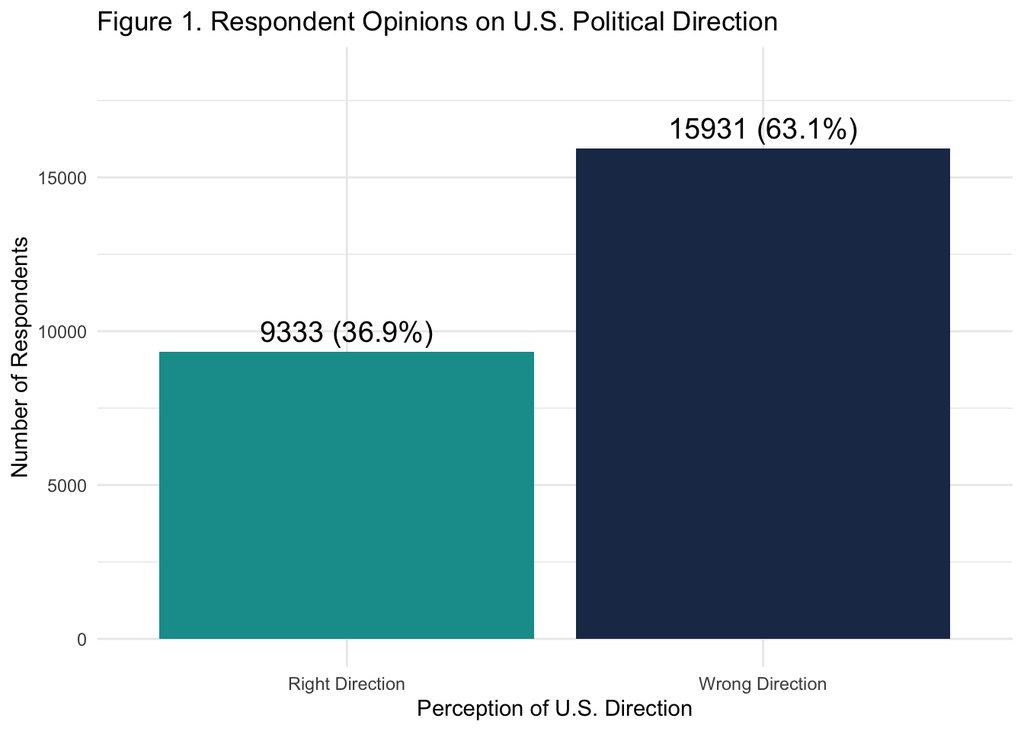

```r
# Uncovering the actual count of responses for each
df_counts <- CompleteDataframe %>%
  count(USPositive) %>%
  mutate(
    Response = ifelse(USPositive == 1, "Right Direction", "Wrong Direction"),
    Percent = round(100 * n / sum(n), 1),
    Label = paste0(n, " (", Percent, "%)")
  )

# Graphing responses
ggplot(df_counts, aes(x = Response, y = n, fill = Response)) +
  geom_col(show.legend = FALSE) +
  geom_text(aes(label = Label), vjust = -0.5, size = 5) +
  labs(
    title = "Figure 1. Respondent Opinions on U.S. Political Direction",
    x = "Perception of U.S. Direction",
    y = "Number of Respondents"
  ) +
  ylim(0, max(df_counts$n) * 1.15) +
  scale_fill_manual(values = c(
    "Right Direction" = "#149B9B",
    "Wrong Direction" = "#1F3556"
  )) +
  theme_minimal()
```

```r
# Developing summary statistics
summary(CompleteDataframe %>% select(USPositive, AgeNumeric, IdeologyNumeric))
```

```
   USPositive       AgeNumeric    IdeologyNumeric
 Min.   :0.0000   Min.   :15.00   Min.   : 1.000
 1st Qu.:0.0000   1st Qu.:35.00   1st Qu.: 4.000
 Median :0.0000   Median :51.00   Median : 5.000
 Mean   :0.3694   Mean   :50.14   Mean   : 5.424
 3rd Qu.:1.0000   3rd Qu.:65.00   3rd Qu.: 7.000
 Max.   :1.0000   Max.   :99.00   Max.   :10.000
```

```r
CompleteDataframe %>%
  select(USPositive, AgeNumeric, IdeologyNumeric) %>%
  summary() %>%
  knitr::kable(caption = "Summary Statistics of Variables") #wrapping the summary so that it renders as a table
```

Summary Statistics of Variables

|  | USPositive | AgeNumeric | IdeologyNumeric |
| --- | --- | --- | --- |
|  | Min. :0.0000 | Min. :15.00 | Min. : 1.000 |
|  | 1st Qu.:0.0000 | 1st Qu.:35.00 | 1st Qu.: 4.000 |
|  | Median :0.0000 | Median :51.00 | Median : 5.000 |
|  | Mean :0.3694 | Mean :50.14 | Mean : 5.424 |
|  | 3rd Qu.:1.0000 | 3rd Qu.:65.00 | 3rd Qu.: 7.000 |
|  | Max. :1.0000 | Max. :99.00 | Max. :10.000 |

## 6 Model Fitting and Hypothesis Testing

To test the hypothesis, I utilize a Multiple Linear Regression model. Since the outcome variable is binary, this approach is interpreted as a Linear Probability Model (LPM). This is a standard approach in econometrics (Angrist & Pischke, 2009, pp. 45-48) that allows for direct interpretation of coefficients as percentage-point changes in probability. While the analysis is informed by a causal framework, the results are interpreted as conditional associations rather than causal effects due to the cross-sectional nature of the data. Specifically, after holding political ideology, gender, and social class constant (condition), age is statistically associated with differences in perceptions of U.S. political direction.

### 6.1 Causal Assumptions (DAG)

Figure 2 presents a Directed Acyclic Graph (DAG) representing the hypothesized relationships among variables. Age is treated as an exogenous predictor that may shape respondents’ political ideology, social class, and perceptions of the United States. Gender is also modeled as affecting both ideology and class, given existing research on gender-based differences in political orientation and socioeconomic positioning. Furthermore, social class is positioned in the DAG to influence political ideology, reflecting the idea that economic status and occupational identity can shape political beliefs. All four predictors (age, ideology, class, and gender) are assumed to directly influence respondents’ evaluations of whether the United States is moving in the “right” direction. However, it is this reason why in order to estimate the association between age and U.S. perceptions, I must control for ideology, class, and gender because they are plausibly related to both age and the outcome. This framework helps clarify confounding structures and supports the inclusion of appropriate control variables in the regression analysis.

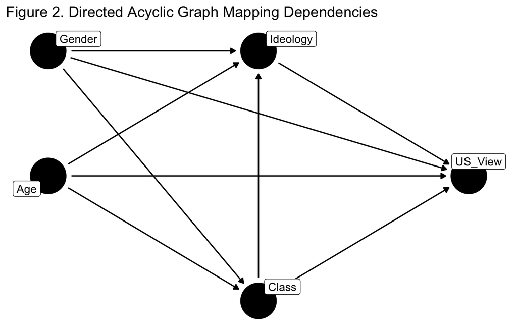

```r
dag_coords <- tibble(
  name = c("Age", "US_View", "Ideology", "Class", "Gender"),
  x = c(1, 3, 2, 2, 1),
  y = c(1, 1, 2, 0, 2)
)

my_dag <- dagify(
  US_View ~ Age + Ideology + Class + Gender,
  Ideology ~ Age + Gender + Class,  # <-- Class added here
  Class ~ Age + Gender,
  coords = dag_coords
)

ggdag(my_dag, text = FALSE, use_labels = "name") +
  labs(title = "Figure 2. Directed Acyclic Graph Mapping Dependencies") +
  theme_dag() +
  theme(legend.position = "none")
```

### 6.2 Regression Results

I fit the following model:

$$Y_i = \beta_0
+ \beta_1 \,\text{Age}_i
+ \beta_2 \,\text{Ideology}_i
+ \beta_3 \,\text{Class}_i
+ \beta_4 \,\text{Gender}_i
+ \epsilon_i$$

```r
model1 <- lm(USPositive ~ AgeNumeric + IdeologyNumeric + Gender + SocialClass, data = CompleteDataframe)

summary(model1)
```

```
Call:
lm(formula = USPositive ~ AgeNumeric + IdeologyNumeric + Gender +
    SocialClass, data = CompleteDataframe)

Residuals:
    Min      1Q  Median      3Q     Max
-0.5773 -0.3819 -0.2940  0.5759  0.8670

Coefficients:
                  Estimate Std. Error t value Pr(>|t|)
(Intercept)      0.4717961  0.0166342  28.363   <2e-16 ***
AgeNumeric      -0.0036574  0.0001650 -22.169   <2e-16 ***
IdeologyNumeric  0.0170917  0.0013539  12.624   <2e-16 ***
Gender          -0.0088500  0.0059739  -1.481    0.139
SocialClass      0.0006552  0.0027978   0.234    0.815
---
Signif. codes:  0 '***' 0.001 '**' 0.01 '*' 0.05 '.' 0.1 ' ' 1

Residual standard error: 0.4766 on 25259 degrees of freedom
Multiple R-squared:  0.02507,   Adjusted R-squared:  0.02492
F-statistic: 162.4 on 4 and 25259 DF,  p-value: < 2.2e-16
```

```r
confint(model1)
```

```
                       2.5 %       97.5 %
(Intercept)      0.439192099  0.504400090
AgeNumeric      -0.003980778 -0.003334031
IdeologyNumeric  0.014437945  0.019745545
Gender          -0.020559219  0.002859208
SocialClass     -0.004828600  0.006139020
```

### 6.3 Confidence Intervals and Uncertainty

To assess the precision of the estimated relationships, 95% confidence intervals were calculated for each regression coefficient. These intervals provide a range of plausible values for the true population effects and offer insight beyond point estimates and p-values.

The confidence interval for Age ranges from −0.00398 to −0.00333, excluding zero. This narrow interval indicates a precisely estimated and consistently negative relationship between age and positive perceptions of U.S. political direction. Substantively, this suggests that older Europeans are systematically less likely to view the United States as moving in the right direction, even when accounting for political ideology, gender, and social class. The tight bounds of the interval reinforce confidence in the direction and magnitude of this association.

Political ideology also exhibits a statistically meaningful relationship. The 95% confidence interval for Ideology spans 0.014 to 0.020, indicating that movement toward the political right is associated with an increased probability of viewing the U.S. favorably. Like age, the interval does not include zero, suggesting a substantively meaningful association.

In contrast, the confidence intervals for Gender (−0.021 to 0.003) and Social Class (−0.005 to 0.006) both include zero, indicating that these effects are not distinguishable from zero at conventional confidence levels. This implies greater uncertainty around the role of gender and class in shaping perceptions of U.S. political direction within this model.

Overall, the confidence intervals reinforce the central finding of the analysis: age and political ideology are the primary correlates of Europeans’ evaluations of U.S. political direction, while other demographic factors play a more limited role. Importantly, the direction of the age effect contradicts the original hypothesis, highlighting a generational pattern that runs counter to expectations derived from traditional soft power theories.

### 6.4 Exploring the Interaction Between Age and Political Ideology

This interaction highlights the complexity of transatlantic attitudes, suggesting that age and ideology posess independent and intersecting influences on how the U.S. is perceived.

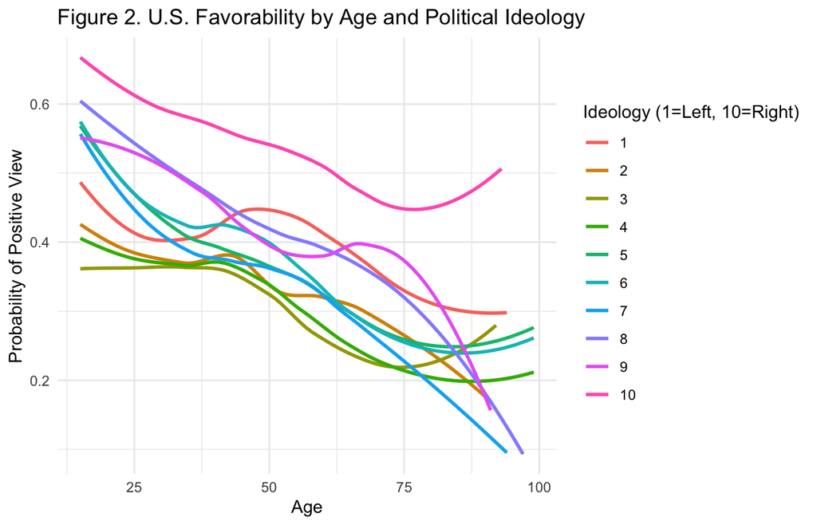

```r
ggplot(CompleteDataframe, aes(x = AgeNumeric, y = USPositive, color = as.factor(IdeologyNumeric))) +
    geom_smooth(method = "loess", se = FALSE) + labs(title = "Figure 2. U.S. Favorability by Age and Political Ideology",
    x = "Age", y = "Probability of Positive View", color = "Ideology (1=Left, 10=Right)") +
    theme_minimal()
```

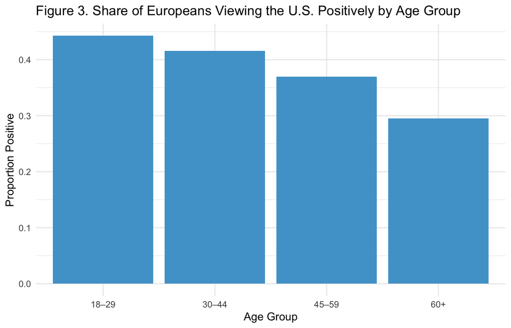

```r
CompleteDataframe %>%
    mutate(AgeGroup = cut(AgeNumeric, breaks = c(18, 29, 44, 59, Inf), labels = c("18–29",
        "30–44", "45–59", "60+"))) %>%
    filter(!is.na(AgeGroup)) %>%
    group_by(AgeGroup) %>%
    summarise(PositiveShare = mean(USPositive)) %>%
    ggplot(aes(x = AgeGroup, y = PositiveShare)) + geom_col(fill = "#4FA3D1") + labs(title = "Figure 3. Share of Europeans Viewing the U.S. Positively by Age Group",
    x = "Age Group", y = "Proportion Positive") + theme_minimal()
```

### 6.5 Interpretation

The regression results support the counterintuitive but statistically significant finding that younger Europeans are more likely to view the United States as moving in the right direction. The coefficient for age is −0.004 and statistically significant (p < 0.001), indicating that for each additional year of age, the probability of holding a positive view of the U.S. decreases by approximately 0.4 percentage points. Substantively, this implies that, holding other factors constant, a 25-year-old is roughly 20 percentage points more likely than a 75-year-old to view the U.S. favorably. This represents a large and meaningful effect in the context of public opinion research.

Political ideology is also a statistically significant predictor of U.S. favorability. Moving one point to the right on the ideological scale is associated with an increase of approximately 1.7 percentage points in the probability of viewing the U.S. positively, indicating a moderate but substantively meaningful effect. Gender and social class, by contrast, are not statistically significant predictors in this model, suggesting that age and ideology account for most of the systematic variation captured by the included covariates.

Taken together, these findings indicate that age is the strongest predictor in the model and that, contrary to expectations rooted in soft power theory, younger cohorts currently hold more favorable views of the United States than older Europeans.

## 7 Diagnostics and Model Evaluation

To ensure the validity of the Linear Probability Model, I examined standard regression diagnostics.

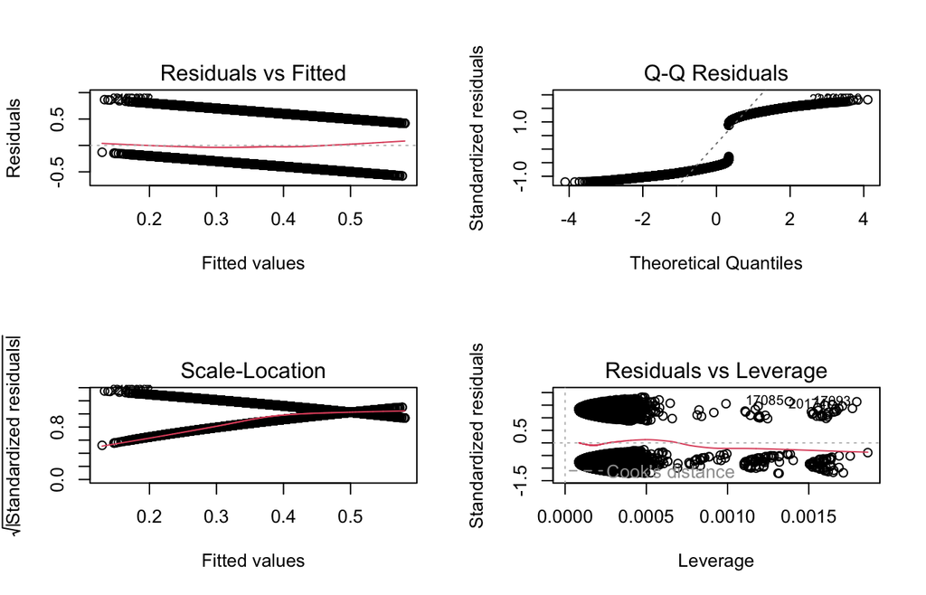

```r
par(mfrow = c(2, 2))
plot(model1)
```

## 8 Discussion

The findings from this analysis indicate a clear and statistically significant association between age and European perceptions of U.S. political direction. Though, contrary to the original hypothesis, younger Europeans are more likely than older respondents to believe that the United States is moving in the “right direction.” This pattern holds even after controlling for political ideology, social class, and gender, suggesting that age captures an independent and meaningful dimension of transatlantic public opinion.

These results challenge the conclusions made in recent surveys that younger generations in Europe are increasingly disillusioned with the United States due to perceived democratic backsliding, foreign policy decisions, or value divergence. Instead, the findings suggest that older Europeans may be more skeptical of the current trajectory of the United States, potentially reflecting longer historical memory, greater exposure to past periods of U.S. unilateralism, or heightened sensitivity to recent geopolitical developments. Younger respondents, by contrast, may evaluate the United States through a different lens, one that is shaped by contemporary cultural, technological, or security-related considerations.

Political ideology remains an important predictor of U.S. favorability, with respondents identifying further to the political right expressing more positive views overall. However, the persistence of the age effect across ideological positions indicates that generational differences cannot be explained solely by partisan orientation. Taken together, these results suggest that age-based patterns in European attitudes toward the United States are more complex than anticipated and may not align neatly with dominant narratives about generational disaffection.

Overall, this study highlights the importance of empirically testing widely held assumptions about public opinion. While existing scholarship often emphasizes a decline in American soft power among younger audiences, the evidence presented here suggests that contemporary generational dynamics may be evolving in unexpected ways. Future research should further explore the mechanisms underlying these age-based differences, particularly through longitudinal-based analyses.

## 9 Limitations

First, the analysis relies on cross-sectional data, which prevents establishing causal relationships. While the results show that younger Europeans are more likely to view the U.S. as moving in the “right direction,” it is not possible to determine whether age itself drives these attitudes or whether unobserved cohort characteristics such as media environments, educational systems, or political events experienced during adolescence, explain the observed relationships. A longitudinal or repeated cross-sectional design would better isolate cohort effects from age or period effects.

Fourth, several potentially important covariates are unavailable in the dataset. Eurobarometer does not measure media consumption, institutional trust, political sophistication, or exposure to international news, all of which may influence attitudes toward the United States. Without such controls, the model risks omitted variable bias. For example, digital media exposure may vary systematically by age and shape views of U.S. politics in ways not captured by the current predictors.

Despite these limitations, the findings remain substantively meaningful. The use of timely, large-scale survey data reveals a generational trend that runs counter to traditional theories of U.S. soft power, where youth are assumed to be the most pro-American. In this case, older Europeans express more skepticism, offering a new and perhaps underexamined perspective on transatlantic political perception.

## 11 References

Angrist, J. D., & Pischke, J.-S. (2009). *Mostly Harmless Econometrics: An Empiricist’s Companion*. Princeton University Press.

Britton, H. (2025, February). *European favourability of the USA falls following the return of Donald Trump*. YouGov. https://yougov.co.uk

Clancy, L. (2023, March 22). *Young adults in Europe are critical of the U.S. and China – but for different reasons*. Pew Research Center. https://www.pewresearch.org

Henley, J. (2025, June 3). *Public support for Israel in western Europe at lowest ever recorded by YouGov*. The Guardian. https://www.theguardian.com

Jennings, M. K., Stoker, L., & Bowers, J. (2009). Politics across generations: Family transmission reexamined. *The Journal of Politics, 71*(3), 782–799. https://doi.org/10.1017/S0022381609090719

Nye, J. S., Jr. (1990). Soft power. *Foreign Policy*, (80), 153–171. https://doi.org/10.2307/1148580

The Economist. (2024, March 13). *Why young men and women are drifting apart: Diverging worldviews could affect politics, families and more*. https://www.economist.com

YouGov. (2025). *Eurotrack survey results: August 13–28, 2025*. https://docs.cdn.yougov.com

Leonard, M., & Gressel, G. (2024, June). *Transatlantic twilight: European public opinion and the long shadow of Trump*. European Council on Foreign Relations. https://ecfr.eu/publication/transatlantic-twilight-european-public-opinion-and-the-long-shadow-of-trump/